# Introduction to R - R Ladies Vienna

Pia Pfeiffer and Patricia Puchhammer

2025-10-28

## What is R? https://www.r-project.org/

> R is a programming language and software environment specifically designed for statistical computing and graphics. It provides a wide variety of statistical and graphical techniques, making it a preferred tool for data analysis and visualization among statisticians, data scientists, researchers, and analysts […] across various industries and domains.
- Firms like Google, Pfizer, Bank of America, Amazon and Microsoft use R for their statistical analyses.
- R is open source! freely available for anyone to use, modify, and distribute, active community

### Statistics

- Most classical statistics and much of the latest methodology is available for use with R
- A few of these are built into the base R environment, but many are supplied as packages available through the *The Comprehensive R Archive Network* (CRAN, https://CRAN.R-project.org)
- Visualization: publication-quality plots and charts
- Reproducibility: R promotes reproducible research by enabling users to document their analyses in a script format.

### Workshop Content

- Intro to RStudio
- Basic data types and structures
- Import and export of data sets
- Basic data processing
- Basic data visualization and `ggplot2`
- Loops, functions, and conditional statements

## Getting Started

### Getting help

R is a collaborative project with many contributors. Type ‘contributors()’ for more information and ‘citation()’ on how to cite R or R packages in publications. Type ‘demo()’ for some demos, ‘help()’ or **‘?’** for on-line help, or ‘help.start()’ for an HTML browser interface to help. Type ‘q()’ to quit R.

- Beginner’s guide: https://support.posit.co/hc/en-us/articles/201141096-Getting-Started-with-R
- Manual: https://cran.r-project.org/doc/manuals/r-release/R-intro.pdf
- R Cookbook: https://rc2e.com/
- R for Data Science: https://r4ds.hadley.nz/

### Installation

- Downloading and installing R. https://cran.r-project.org/
- Downloading and installing RStudio. https://posit.co/downloads/
- Download code for R Introduction from https://github.com/patriciapuch/

### RStudio

- RStudio is an integrated development environment (IDE) for R.
- It includes a console, syntax-highlighting editor that supports direct code execution, as well as tools for plotting, history, debugging and workspace management.
- RStudio is available in open source and commercial editions.
- RStudio runs on the desktop (Windows, Mac, and Linux) or in a browser connected to RStudio Server or RStudio Server Pro (Debian/Ubuntu, RedHat/CentOS, and SUSE Linux).
- Introduction to RStudio interface.

### Basic commands and arithmetic operations

- Using R as a calculator

```r
3 + 4
```

```
## [1] 7
```

```r
3 - 7
```

```
## [1] -4
```

```r
2 * 20
```

```
## [1] 40
```

```r
4/2
```

```
## [1] 2
```

```r
10^3
```

```
## [1] 1000
```

```r
sqrt(10)
```

```
## [1] 3.162278
```

- Comparisons

```r
3 < 5
```

```
## [1] TRUE
```

```r
3 > 5
```

```
## [1] FALSE
```

```r
3 <= 5
```

```
## [1] TRUE
```

```r
3 >= 5
```

```
## [1] FALSE
```

```r
3 == 5     # Attention: double equal sign
```

```
## [1] FALSE
```

```r
3 != 5
```

```
## [1] TRUE
```

### Variables

- Assignment

```r
x <- 3
y = 4
z <- y + 1
```

## Data Structures

Creating and manipulating data structures.

- Atomic vectors (elements are same type)

```r
pyth_triple <- c(x, y, z)
?c
```

```
## starte den http Server für die Hilfe fertig
```

```r
# indexing with boolean (condition)
pyth_triple[pyth_triple >= 4]
```

```
## [1] 4 5
```

- Factors (for categorical data, can be ordered, levels are unique values)

```r
x1 <- c("Dec", "Apr", "Jam", "Mar")
sort(x1)
```

```
## [1] "Apr" "Dec" "Jam" "Mar"
```

```r
month_levels <- c(
  "Jan", "Feb", "Mar", "Apr", "May", "Jun",
  "Jul", "Aug", "Sep", "Oct", "Nov", "Dec"
)
y1 <- factor(x1, levels = month_levels)
y1
```

```
## [1] Dec  Apr  <NA> Mar
## Levels: Jan Feb Mar Apr May Jun Jul Aug Sep Oct Nov Dec
```

```r
sort(y1)
```

```
## [1] Mar Apr Dec
## Levels: Jan Feb Mar Apr May Jun Jul Aug Sep Oct Nov Dec
```

- Matrices (2-dimensional generalization of vectors)

```r
mat <- matrix(0, nrow = 5, ncol = 5)
diag(mat) <- c(seq(1, 2, by = 1), seq(4, 2, by = -1))
mat
```

```
##      [,1] [,2] [,3] [,4] [,5]
## [1,]    1    0    0    0    0
## [2,]    0    2    0    0    0
## [3,]    0    0    4    0    0
## [4,]    0    0    0    3    0
## [5,]    0    0    0    0    2
```

- Data Frames (matrix-like structures, can handle different data types)

```r
v_char <- c("Lucy", "Stefanie", "Florian", "Michelle", "Jacky", "Anna", "Pia", "Markus")
v_num <- c(18, 20, 22, 30, 29, 50, 38, 25)
v_bool <- c(TRUE, TRUE, FALSE, TRUE, TRUE, TRUE, TRUE, FALSE)
df <- data.frame(name = v_char,
                 age = v_num,
                 female_names = v_bool)
df$name[df$female_names] #indexing
```

```
## [1] "Lucy"     "Stefanie" "Michelle" "Jacky"    "Anna"     "Pia"
```

```r
df$age[df$age > 25]
```

```
## [1] 30 29 50 38
```

- Lists (general form of vector, elements can be of different type)

```r
my_list <- list(matrix = mat,
                vector = pyth_triple,
                fact = y1,
                bool = TRUE)
```

## Packages

- CRAN: https://cran.r-project.org/
- Bioconductor: https://www.bioconductor.org/
- find packages that might be useful for your field: https://cran.r-project.org/web/views/
- popular packages for Data Science are combined in ‘tidyverse’ https://www.tidyverse.org/ (**ggplot2**, dplyr, tidyr, readr, stringr, …)
- Installation (CRAN)

```r
install.packages("tidyverse")
```

- get help with packages and functions

```r
library(tidyverse)
help(package = "tidyverse")
```

## Data Import and Export

- Importing data from CSV, Excel, text files.

```r
?read.table

path1 <- file.path("iris", "iris_1.csv")
path2 <- file.path("iris", "iris_2.csv")
path3 <- file.path("iris", "iris_3.txt")
path4 <- file.path("iris", "iris_4.txt")

iris1 <- read.csv(path1, header = F)
iris2 <- read.csv2(path2, dec = ",")
iris3 <- read.table(path3, header = T)
iris4 <- read.table(path4, header = T)

head(iris1) # look at data
```

```
##         V1           V2          V3           V4          V5      V6
## 1 rownames Sepal.Length Sepal.Width Petal.Length Petal.Width Species
## 2        1          5.1         3.5          1.4         0.2  setosa
## 3        2          4.9           3          1.4         0.2  setosa
## 4        3          4.7         3.2          1.3         0.2  setosa
## 5        4          4.6         3.1          1.5         0.2  setosa
## 6        5            5         3.6          1.4         0.2  setosa
```

- Data cleaning and preprocessing.
- Useful package `janitor`: https://cran.r-project.org/web/packages/janitor/index.html

```r
iris1 <- read.csv(path1, header = T)
?iris

# selecting and naming columns
iris_new <- iris1[,2:6]
colnames(iris_new) <- c("sepal_l", "sepal_w", "petal_l", "petal_w", "species")

# missing values
iris_new[5,2] <- NA
mean(iris_new[,2])
```

```
## [1] NA
```

```r
iris_new <- na.omit(iris_new)
mean(iris_new[,2])
```

```
## [1] 3.053691
```

```r
# modifying columns
iris_new$total_l <- iris_new$sepal_l + iris_new$petal_l
iris_new$total_w <- iris_new$sepal_w + iris_new$petal_w
iris_new$species <- factor(iris_new$species, levels = c( "setosa", "versicolor", "virginica"))
head(iris_new)
```

```
##   sepal_l sepal_w petal_l petal_w species total_l total_w
## 1     5.1     3.5     1.4     0.2  setosa     6.5     3.7
## 2     4.9     3.0     1.4     0.2  setosa     6.3     3.2
## 3     4.7     3.2     1.3     0.2  setosa     6.0     3.4
## 4     4.6     3.1     1.5     0.2  setosa     6.1     3.3
## 6     5.4     3.9     1.7     0.4  setosa     7.1     4.3
## 7     4.6     3.4     1.4     0.3  setosa     6.0     3.7
```

- Exporting data.

```r
?write.table

write.csv(iris_new, file = file.path("iris", "iris_mod.csv"))

save(iris_new, file = file.path("iris", "iris_mod.Rdata"))
rm(iris_new)
load(file = file.path("iris", "iris_mod.Rdata"))
```

- package for data wrangling: ‘dplyr’ https://dplyr.tidyverse.org/

## Data Visualization

- Creating and modifying plots with base R.

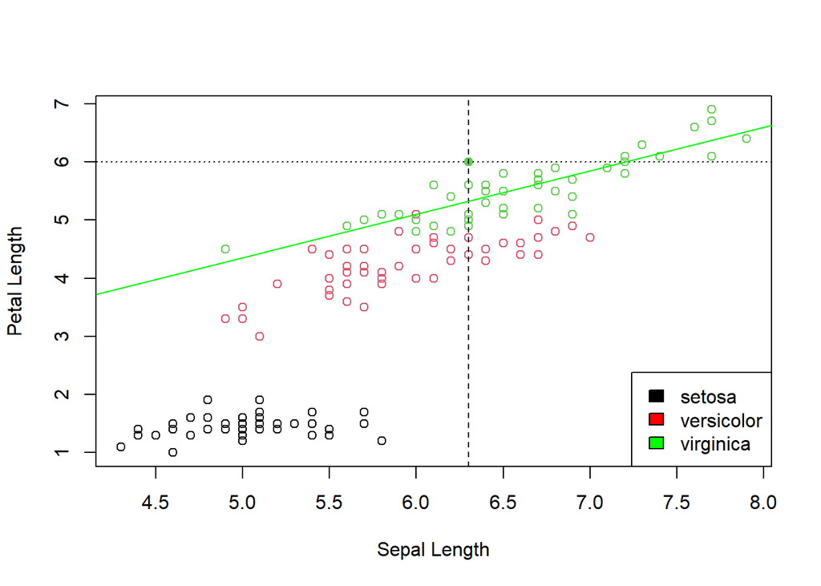

```r
plot(iris_new$sepal_l, iris_new$petal_l,
     type = "p",
     col = iris_new$species,
     xlab = "Sepal Length", ylab = "Petal Length")
points(iris_new$sepal_l[100], iris_new$petal_l[100],
       pch = 19,
       col = iris_new$species[100])
legend("bottomright",
       fill = c("black", "red", "green"),
       legend = levels(iris_new$species))
abline(v = iris_new$sepal_l[100], lty = 2)
abline(h = iris_new$petal_l[100], lty = 3)
abline(coef = c(0.6, 0.75), col = "green")
```

- multivariate: pairs

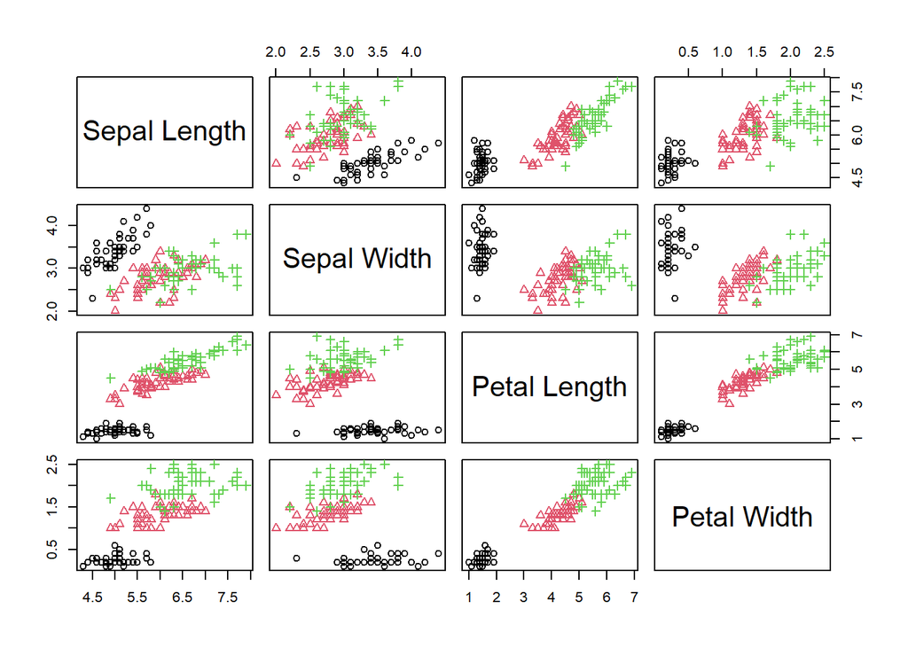

```r
pairs(iris_new[,1:4],
      col = iris_new$species,
      pch = as.numeric(iris_new$species),
      labels = c("Sepal Length", "Sepal Width", "Petal Length", "Petal Width"))
```

- Export of plots
- ggplot2 https://ggplot2.tidyverse.org/

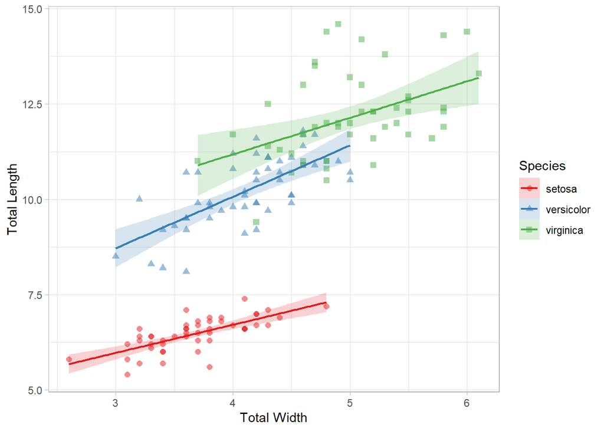

```r
library(ggplot2)

ggplot(data = iris_new,
       aes(x = total_w,
           y = total_l,
           groups = species,
           col = species)) +
  geom_point(aes(pch = species),
             size = 2, alpha = 0.5) +
  geom_smooth(aes(fill = species),
              method = "lm",
              alpha = 0.2, linewidth = 0.75) +
  xlab("Total Width") + ylab("Total Length") +
  labs(col = "Species",
       pch = "Species",
       fill = "Species") +
  scale_color_brewer(palette = "Set1") +
  scale_fill_brewer(palette = "Set1") +
  theme_light()
```

```r
? scale_color_brewer
? theme_light

# Now its time to make your own plots with ggplot2 :)

? geom_histogram # aes(fill= _, x or y = _)
? geom_boxplot # aes(fill= _, x or y = _)
? geom_qq # aes(sample=_)
? geom_text  # aes(x=_, y=_, label=_)
```

## Programming

- if else

```r
if (3 > 5) {
  print("That's true!")
  } else {
  print("That's false")
  }
```

```
## [1] "That's false"
```

- for, while

```r
for (i in 1:3){
  print(paste("count:", i))
}
```

```
## [1] "count: 1"
## [1] "count: 2"
## [1] "count: 3"
```

```r
j <- 0
while (j < 4){
  print(j)
  j <- j + 1
}
```

```
## [1] 0
## [1] 1
## [1] 2
## [1] 3
```

- functions

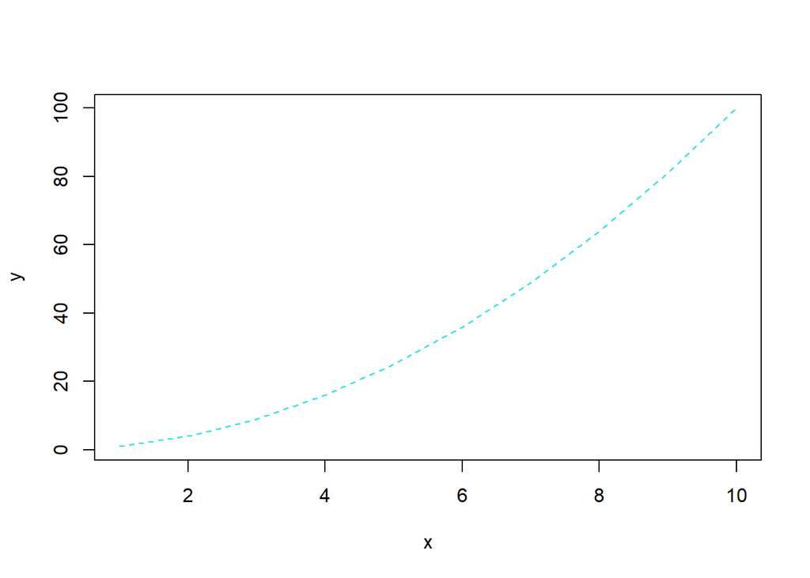

```r
my_plot <- function(x, y, color, linetype) {
  plot(x, y, type = "l", col = color, lty = linetype)
}

my_plot(seq(1,10,1), seq(1,10,1)^2, 5, 2)
```

## R Markdown

- Reporting and reproducible research
- Introduction: https://rmarkdown.rstudio.com/